# Parameter Estimation

# Case Study I: Point Estimate and Standard Error

The goal of parameter estimation is to find a range of possible values (confidence interval).

**Given information**

- $\hat{p} = 0.67 \longleftarrow \text{point estimate}$
- $n = 850 \longleftarrow \text{sample size}$
  - The expected number of users who think the Facebook categorizes their interests accurately is $850 \times 0.67 \approx 569.5$ (569 or 570).
  - There around 280.5 (280 or 281) users think the opposite.
- Let $p$ bet he true population proportion and $\hat{p}$ be the sample proportion.

**The Confidence Interval**

We want to find the 95% confidence interval using the formula:
$$\text{point estimate} \pm 1.96 \times
\text{SE}$$
where **SE is the standard error**.

This can be written as
$$\begin{aligned}
0.67 & \pm 1.96 \times \sqrt{\frac{0.67 (1-0.67)}{850}} \\
0.67 & \pm 1.96 \times 0.0161 \\
& \longrightarrow (0.67-0.0316,0.67+0.0316) \\
& \longrightarrow (0.6384,0.7016)
\end{aligned}$$

Thus, the 95% interval for estimating the true $p$ is between 0.6384 and 0.7016.

# Case Study I: Interpretation

$\dagger$ Why do we interpret the confidence interval this way?

# What does 95% Confident Mean?

Suppose we took many samples and built a confidence interval from each sample using the equation
$$\text{point
estimate} \pm 1.96 \times \text{standard error}.$$

Then about 95% of those intervals would contain the true population proportion ($p$).

# Width of an interval

If we want to be more certain that we capture the population parameter, i.e. increase our confidence level, should we use a wider interval or a smaller interval?

$\star$ A wider interval.

Can you see any drawbacks to using a wider interval?

$\star$ If the interval is too wide it may not be very informative.

# Changing the Confidence Level

$$\text{point estimate} \pm z^{\star}
\times \text{SE}.$$

- In a confidence interval, $z^{\star} \times \text{SE}$ is called the **margin of error**, and for a given sample, the margin of error changes as the confidence level changes.
- In order to change the confidence level we need to adjust $z^{\star}$ in the above formula.
- Commonly used confidence levels in practice are 90%, 95%, 98%, and 99%.
- For a 95% confidence interval, $z^{\star} = 1.96$.
- However, using the standard normal distribution, it is possible to find the appropriate $z^{\star}$ for any confidence level.

# 95% Confidence Interval

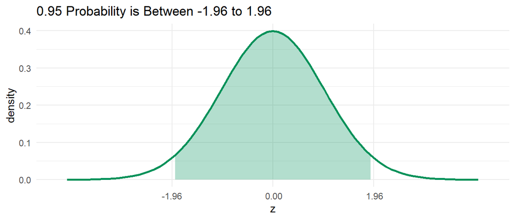

# Example 1

Which of the below Z scores is the appropriate $z^{\star}$ when calculating a 99.7% confidence interval?

1. Z = 2.05
2. Z = 2.33
3. Z = 2.97
4. Z = 1.96

$\star$ Estimating the $z^{\star}$ can be done using the 68-95-99.7 rule. We know that $P(-3 \le Z \le 3) \approx 0.997$. So, the closest answer is $Z = 2.97$.

# Example 1: 99.7% Confidence Interval

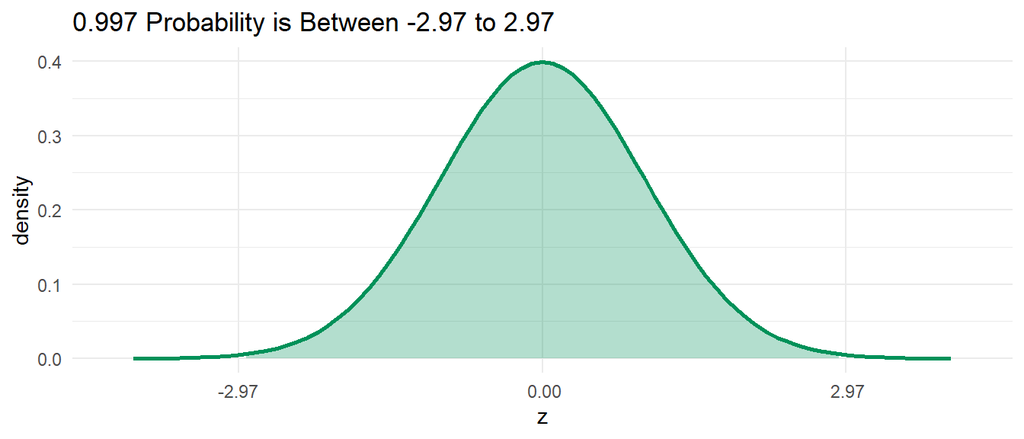

# Finding $z^{\star}$ Exactly

Find the $z^{\star}$ for a 92% confidence level.

**Process:**

- Confidence level is 0.92.
- Lower tail of the $Z \sim N(0,1)$ is $\frac{(1-0.92)}{2} = 0.04$.
- We want to find the $z$ score that would yield a 0.04 probability.
- Use the `qnorm()` function in R.

**Using R:**

```r
cl <- 0.92 # confidence level
lt <- (1-cl)/2 # lower tail probability
qnorm(lt,0,1) # computes the z star
```

```
## [1] -1.750686
```

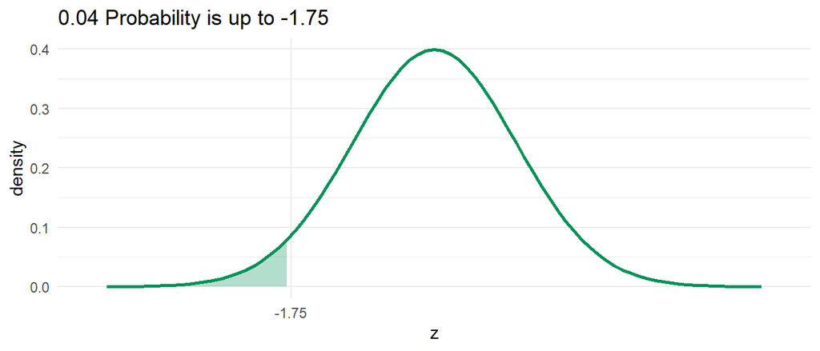

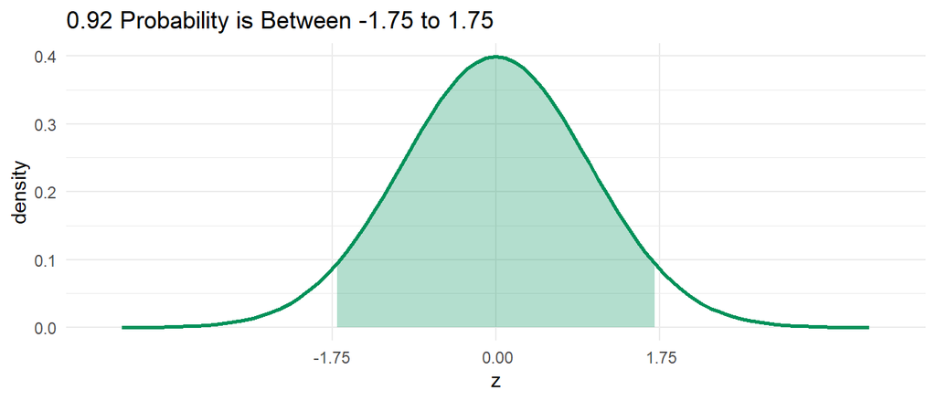

# Activity: Determine and Interpret Confidence Intervals

1. Make sure you have a copy of the *F 3/14 Worksheet*. This will be handed out physically and it is also digitally available on Moodle.
2. Work on your worksheet by yourself for 10 minutes. Please read the instructions carefully. Ask questions if anything need clarifications.
3. Get together with another student.
4. Discuss your results.
5. Submit your worksheet on Moodle as a `.pdf` file.

# References

Diez, D. M., Barr, C. D., & Çetinkaya-Rundel, M. (2012). *OpenIntro statistics* (4th ed.). OpenIntro. https://www.openintro.org/book/os/

Speegle, Darrin and Clair, Bryan. (2021). *Probability, statistics, and data: A fresh approach using r*. Chapman; Hall/CRC. https://probstatsdata.com/